# Robustness checks

Arturo Bertero

2024-04-15

# Introduction

In this report I perform several robustness checks and modifications.

1. I take the **absolute values** for the np_w measures

```r
# np_w as absoulte value
data$EES_COR_np_w = abs(data$EES_COR_np_w)
data$EES_GGM_glasso_np_w = abs(data$EES_GGM_glasso_np_w)
data$EES_GGM_huge_np_w = abs(data$EES_GGM_huge_np_w)
```

2. I **rescale** all variables from 0 to 1. I did not rescale the measures that are already on a 0 to 1 scale, such as the constraint measures, ihdi, p_inst. *Is the procedure (and is the code) correct?*

```r
# rescale function
rescale01 <- function(x) {(x - min(x)) / (max(x) - min(x))}

# Manually applying the function
data$EES_GGM_glasso_aspl = rescale01(data$EES_GGM_glasso_aspl)
data$EES_GGM_glasso_np_i = rescale01(data$EES_GGM_glasso_np_i)
data$EES_GGM_glasso_np_w = rescale01(data$EES_GGM_glasso_np_w)
data$EES_GGM_huge_aspl = rescale01(data$EES_GGM_huge_aspl)
data$EES_GGM_huge_np_i = rescale01(data$EES_GGM_huge_np_i)
data$EES_GGM_huge_np_w = rescale01(data$EES_GGM_huge_np_w)
data$EES_COR_aspl = rescale01(data$EES_COR_aspl)
data$EES_COR_np_i = rescale01(data$EES_COR_np_i)
data$EES_COR_np_w = rescale01(data$EES_COR_np_w)
data$educ = rescale01(data$educ)
data$ideol = rescale01(data$ideol)
data$mass_mob = rescale01(data$mass_mob)
data$p_inst_k = rescale01(data$p_inst_k)
data$pint = rescale01(data$pint)
data$pola = rescale01(data$pola)
data$turnout = rescale01(data$turnout)
data$ENEP = rescale01(data$ENEP)
data$gallagher = rescale01(data$gallagher)
```

3. **Visualization of mismatches** between constraint and aspl

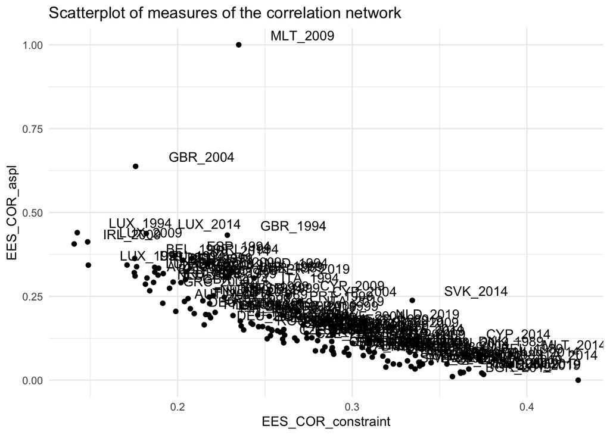

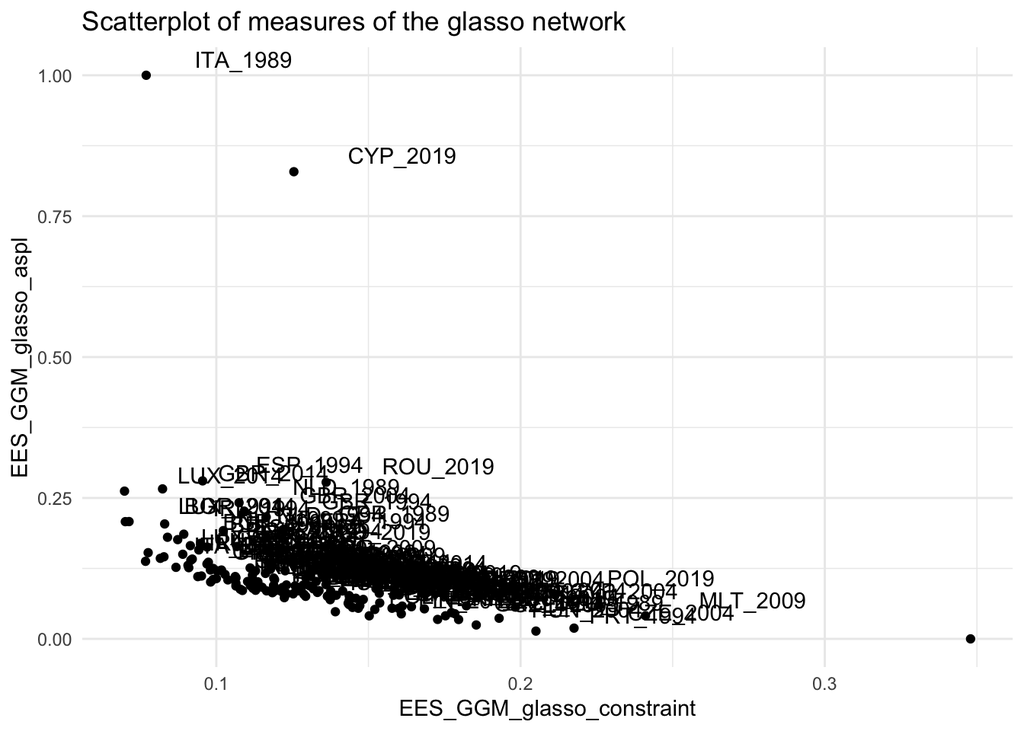

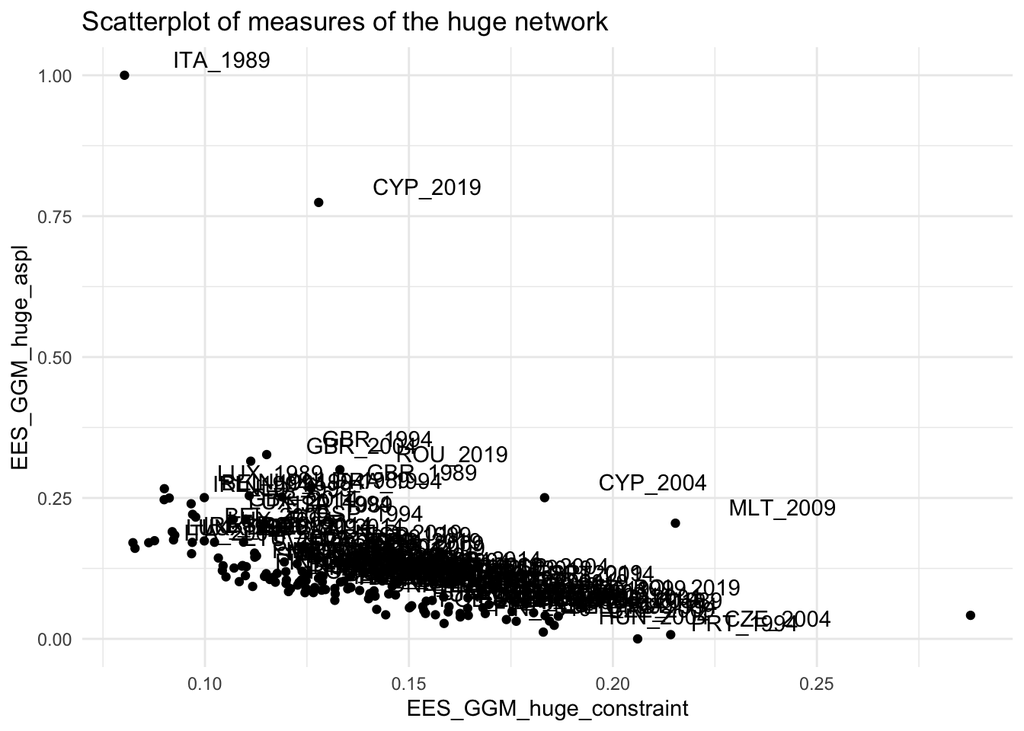

As Ita_1989 is outlier (very high ASPL, with low constraint) I show you this network:

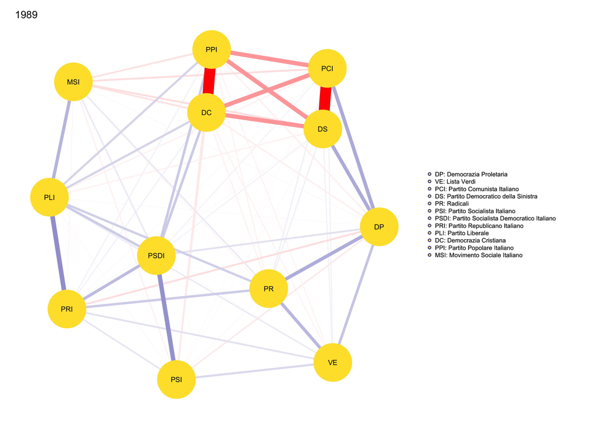

Outlier case: Italy 1989

4. Now I remove **outliers** for aspl measures. The final sample is thus composed of 138 rather than 143 country_year units.

```r
#robustness: remove outliers from aspl

# filter outliers
num_sd <- 3

# cor
# Calculate mean and sd
mean_aspl <- mean(data$EES_COR_aspl, na.rm = TRUE)
sd_aspl <- sd(data$EES_COR_aspl, na.rm = TRUE)

# Filter out outliers
data <- data %>%
  filter(EES_COR_aspl > (mean_aspl - num_sd * sd_aspl) & EES_COR_aspl < (mean_aspl + num_sd * sd_aspl))

# glasso
# Calculate mean and sd
mean_aspl <- mean(data$EES_GGM_glasso_aspl, na.rm = TRUE)
sd_aspl <- sd(data$EES_GGM_glasso_aspl, na.rm = TRUE)

# Filter out outliers
data <- data %>%
  filter(EES_GGM_glasso_aspl > (mean_aspl - num_sd * sd_aspl) & EES_GGM_glasso_aspl < (mean_aspl + num_sd * sd_aspl))

# huge
# Calculate mean and sd
mean_aspl <- mean(data$EES_GGM_huge_aspl, na.rm = TRUE)
sd_aspl <- sd(data$EES_GGM_huge_aspl, na.rm = TRUE)

# Filter out outliers
data <- data %>%
  filter(EES_GGM_huge_aspl > (mean_aspl - num_sd * sd_aspl) & EES_GGM_huge_aspl < (mean_aspl + num_sd * sd_aspl))
```

# Descriptives

Same plots, with the trimmed distributions

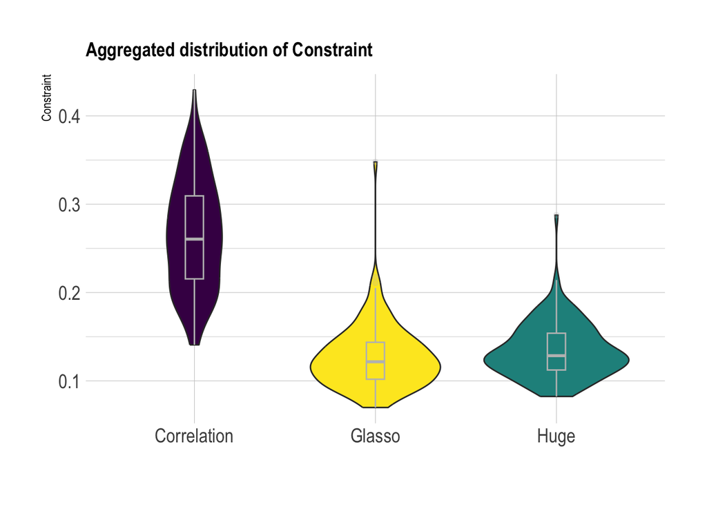

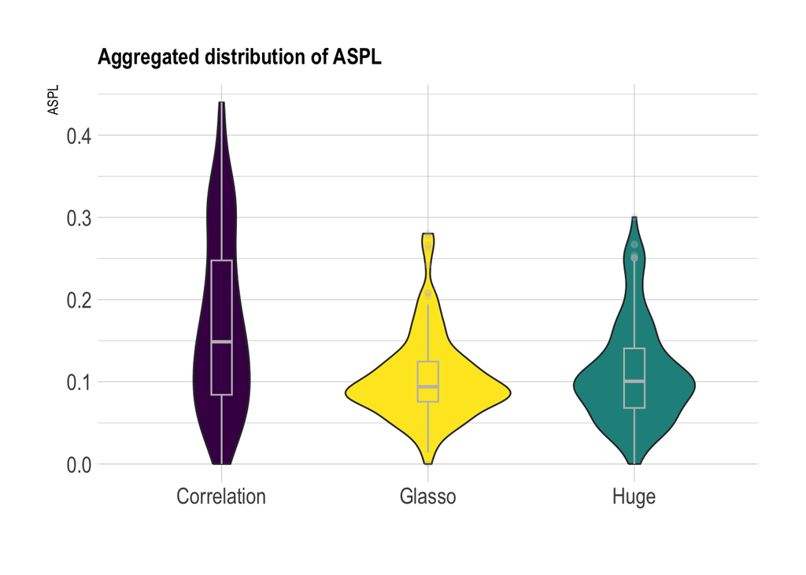

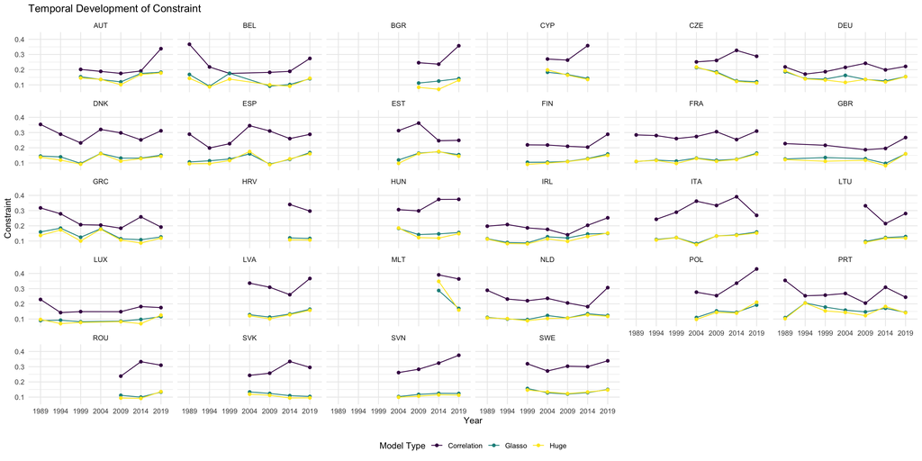

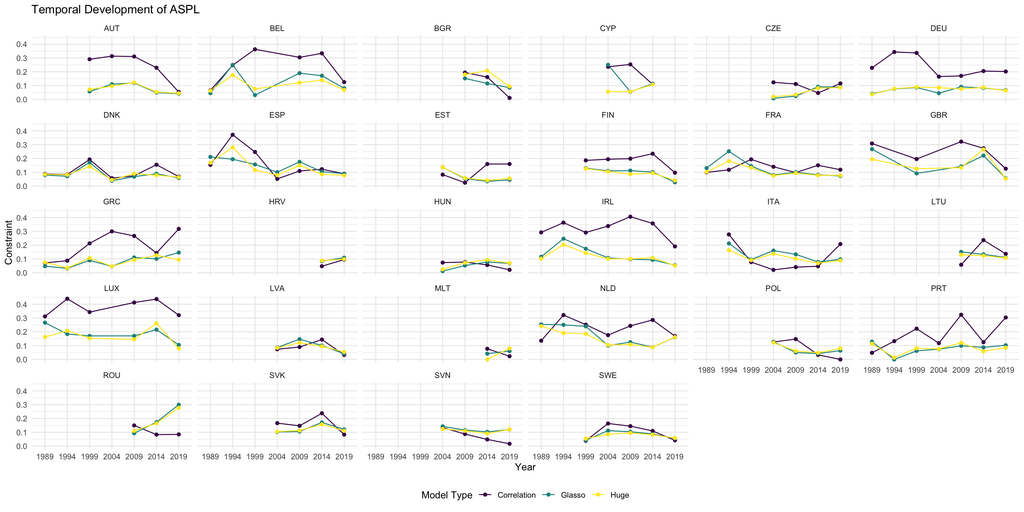

# Part 1: What does predict network connectivity?

In this part of the report I re-estimate the Bayesian Model Averaging on the new data set. Results change both in terms of coefficients (and their pvalues) and in terms of suggested variable selection. In the summary paragraph I discuss how this marginally impact on the final results.

## Determinants of constraint

### Correlational networks

OLS fixed effects (country and years) on constraint of cor network

M1

M2

M3

Estimates

Estimates

Estimates

pint

-0.08 **  
(-0.15 – -0.02)

-0.08 **  
(-0.15 – -0.02)

-0.09 ***  
(-0.16 – -0.03)

pola

0.17 **  
(0.04 – 0.30)

0.10  
(-0.04 – 0.25)

alt_inf

-0.17 *  
(-0.35 – 0.01)

Observations

138

138

138

R<sup>2</sup> / R<sup>2</sup> adjusted

0.681 / 0.575

0.700 / 0.597

0.711 / 0.607

AIC

-462.675

-469.414

-472.188

- p<0.1 ** p<0.05 *** p<0.01

### Glasso networks

OLS fixed effects (country and years) on constraint of glasso network

M1

M2

M3

Estimates

Estimates

Estimates

p_inst

0.37 **  
(0.04 – 0.70)

0.36 **  
(0.03 – 0.68)

0.39 **  
(0.06 – 0.72)

ENEP

-0.05 *  
(-0.10 – 0.01)

-0.04  
(-0.09 – 0.02)

pint

0.02  
(-0.03 – 0.07)

Observations

138

138

138

R<sup>2</sup> / R<sup>2</sup> adjusted

0.519 / 0.360

0.532 / 0.372

0.536 / 0.371

AIC

-555.345

-557.293

-556.390

- p<0.1 ** p<0.05 *** p<0.01

### Huge networks

OLS fixed effects (country and years) on constraint of huge network

M1

M2

M3

Estimates

Estimates

Estimates

p_inst

0.34 **  
(0.06 – 0.62)

0.33 **  
(0.05 – 0.60)

0.35 **  
(0.07 – 0.64)

ENEP

-0.04  
(-0.08 – 0.01)

-0.03  
(-0.08 – 0.02)

pint

0.02  
(-0.02 – 0.06)

Observations

138

138

138

R<sup>2</sup> / R<sup>2</sup> adjusted

0.523 / 0.365

0.534 / 0.374

0.537 / 0.372

AIC

-600.133

-601.350

-600.470

- p<0.1 ** p<0.05 *** p<0.01

## Determinant of ASPL

### Correlational networks

OLS fixed effects (country and years) on ASPL of correlational network

M1

M2

M3

Estimates

Estimates

Estimates

pint

0.17 ***  
(0.05 – 0.28)

0.17 ***  
(0.05 – 0.28)

0.17 ***  
(0.05 – 0.28)

pola

-0.30 ***  
(-0.53 – -0.08)

-0.29 **  
(-0.52 – -0.05)

mass_mob

-0.03  
(-0.15 – 0.08)

Observations

138

138

138

R<sup>2</sup> / R<sup>2</sup> adjusted

0.677 / 0.570

0.699 / 0.595

0.699 / 0.592

AIC

-309.615

-317.248

-315.700

- p<0.1 ** p<0.05 *** p<0.01

### Glasso networks

OLS fixed effects (country and years) on ASPL of glasso network

M1

M2

M3

Estimates

Estimates

Estimates

p_inst

-0.72 ***  
(-1.17 – -0.26)

-0.83 ***  
(-1.29 – -0.37)

-0.87 ***  
(-1.32 – -0.41)

pola

-0.15 **  
(-0.28 – -0.02)

-0.15 **  
(-0.28 – -0.02)

educ

0.12  
(-0.04 – 0.28)

Observations

138

138

138

R<sup>2</sup> / R<sup>2</sup> adjusted

0.544 / 0.394

0.566 / 0.417

0.576 / 0.425

AIC

-463.167

-467.905

-469.016

- p<0.1 ** p<0.05 *** p<0.01

### Huge networks

OLS fixed effects (country and years) on ASPL of huge network

M1

M2

M3

Estimates

Estimates

Estimates

p_inst

-0.88 ***  
(-1.44 – -0.31)

-1.03 ***  
(-1.60 – -0.47)

-0.92 ***  
(-1.50 – -0.35)

pola

-0.20 **  
(-0.36 – -0.04)

-0.26 ***  
(-0.44 – -0.09)

alt_inf

-0.19 *  
(-0.41 – 0.03)

Observations

138

138

138

R<sup>2</sup> / R<sup>2</sup> adjusted

0.510 / 0.348

0.537 / 0.378

0.550 / 0.390

AIC

-405.477

-411.486

-413.347

- p<0.1 ** p<0.05 *** p<0.01

### Summary: which are the main predictors?

To summarize results I build a set of OLS models with: 1. Country and year fixed effects (like in all models) 2. Pola 3. pint 4. p_inst

Results show party institutionalization is the most solid predictor: it is associated with the aspls of pcor network and with their constraint. Interestingly, the constraint and aspl of the cor network is best predicted by pola and pint. Once again, pint produces opposite predictions: it decreases the constraint of a cor network, it has positive coefficient for the aspl of a cor network.

OLS fixed effects (country and years) common model for all DV

Cor_const

glasso_const

huge_const

Cor_aspl

glasso_aspl

huge_aspl

Estimates

Estimates

Estimates

Estimates

Estimates

Estimates

pola

0.16 **  
(0.03 – 0.29)

0.05  
(-0.05 – 0.14)

0.05  
(-0.03 – 0.14)

-0.33 ***  
(-0.56 – -0.10)

-0.15 **  
(-0.28 – -0.02)

-0.20 **  
(-0.37 – -0.04)

p_inst

-0.00  
(-0.49 – 0.48)

0.44 **  
(0.09 – 0.80)

0.39 **  
(0.09 – 0.70)

-0.35  
(-1.21 – 0.51)

-0.81 ***  
(-1.30 – -0.32)

-0.97 ***  
(-1.58 – -0.37)

pint

-0.10 **  
(-0.17 – -0.02)

0.03  
(-0.03 – 0.08)

0.02  
(-0.02 – 0.07)

0.16 **  
(0.03 – 0.29)

0.03  
(-0.05 – 0.10)

0.04  
(-0.05 – 0.13)

Observations

138

138

138

138

138

138

R<sup>2</sup> / R<sup>2</sup> adjusted

0.715 / 0.601

0.544 / 0.363

0.547 / 0.366

0.701 / 0.582

0.581 / 0.415

0.551 / 0.373

AIC

-468.191

-552.868

-597.259

-310.496

-464.802

-407.776

- p<0.1 ** p<0.05 *** p<0.01

# Part 2: What are the consequences of network characteristics?

Also in Part 2 I apply modifications.

1. **Rescale** all predictors that are not in a 0 to 1 scale yet.
2. Remove **outliers for turnout**: zero observation with the sd = 3 criteria
3. Take the **absolute for np_w** measures
4. Remove **outliers for the np_i** measure: from 143 to 136 observation
5. Remove **outliers for the np_w** measure: from 136 to 126 observation

### Does connectivity predict turnout?

Turnout = mandatory voting + measure of connectivity/network type + country F.E. + year F.E. No results

OLS fixed effects (country and years) common model for all DV

Cor_const

glasso_const

huge_const

Cor_aspl

glasso_aspl

huge_aspl

Estimates

Estimates

Estimates

Estimates

Estimates

Estimates

mand

0.45 ***  
(0.32 – 0.58)

0.48 ***  
(0.35 – 0.62)

0.48 ***  
(0.35 – 0.62)

0.44 ***  
(0.31 – 0.58)

0.46 ***  
(0.33 – 0.59)

0.46 ***  
(0.33 – 0.59)

EES_COR_constraint

-0.22  
(-0.66 – 0.22)

EES_GGM_glasso_constraint

0.39  
(-0.35 – 1.13)

EES_GGM_huge_constraint

0.38  
(-0.43 – 1.19)

EES_COR_aspl

0.10  
(-0.18 – 0.37)

EES_GGM_glasso_aspl

0.04  
(-0.13 – 0.20)

EES_GGM_huge_aspl

0.03  
(-0.14 – 0.20)

Observations

126

126

126

126

126

126

R<sup>2</sup> / R<sup>2</sup> adjusted

0.898 / 0.860

0.899 / 0.861

0.898 / 0.860

0.898 / 0.860

0.898 / 0.859

0.897 / 0.859

AIC

-219.752

-219.856

-219.541

-219.012

-218.603

-218.560

- p<0.1 ** p<0.05 *** p<0.01

### Do the ratio measures predict greater turnout?

Turnout = mand + measure of ratio/network type + country F.E. + year F.E. Results are robust to outliers

OLS fixed effects (country and years) common model for all DV

Cor_const

glasso_const

huge_const

Cor_aspl

glasso_aspl

huge_aspl

Estimates

Estimates

Estimates

Estimates

Estimates

Estimates

mand

0.49 ***  
(0.36 – 0.61)

0.51 ***  
(0.38 – 0.64)

0.48 ***  
(0.36 – 0.61)

0.53 ***  
(0.40 – 0.66)

0.49 ***  
(0.36 – 0.61)

0.53 ***  
(0.40 – 0.66)

EES_COR_np_i

0.32 ***  
(0.14 – 0.50)

EES_COR_np_w

0.66 **  
(0.15 – 1.17)

EES_GGM_glasso_np_i

0.43 **  
(0.09 – 0.78)

EES_GGM_glasso_np_w

0.88 ***  
(0.33 – 1.43)

EES_GGM_huge_np_i

0.18 **  
(0.01 – 0.35)

EES_GGM_huge_np_w

1.37 ***  
(0.48 – 2.25)

Observations

126

126

126

126

126

126

R<sup>2</sup> / R<sup>2</sup> adjusted

0.910 / 0.876

0.904 / 0.868

0.904 / 0.868

0.908 / 0.873

0.902 / 0.865

0.907 / 0.872

AIC

-234.644

-227.098

-226.965

-231.615

-224.289

-230.798

- p<0.1 ** p<0.05 *** p<0.01

Full model: Turnout = mand + measure of ratio/network type + gdp + infla + ihdi + pola + ENEP + country F.E. + year F.E. The weighted measure is significant across all models. The integer measure is more unstable.

OLS fixed effects (country and years) common model for all DV

Cor_const

glasso_const

huge_const

Cor_aspl

glasso_aspl

huge_aspl

Estimates

Estimates

Estimates

Estimates

Estimates

Estimates

mand

0.47 ***  
(0.30 – 0.64)

0.48 ***  
(0.30 – 0.66)

0.44 ***  
(0.26 – 0.62)

0.50 ***  
(0.31 – 0.68)

0.45 ***  
(0.27 – 0.63)

0.49 ***  
(0.30 – 0.67)

EES_COR_np_i

0.33 ***  
(0.15 – 0.50)

EES_COR_np_w

0.68 ***  
(0.17 – 1.19)

EES_GGM_glasso_np_i

0.44 **  
(0.10 – 0.78)

EES_GGM_glasso_np_w

0.84 ***  
(0.27 – 1.41)

EES_GGM_huge_np_i

0.17 *  
(-0.00 – 0.34)

EES_GGM_huge_np_w

1.29 ***  
(0.37 – 2.20)

Observations

126

126

126

126

126

126

R<sup>2</sup> / R<sup>2</sup> adjusted

0.917 / 0.880

0.912 / 0.872

0.911 / 0.871

0.913 / 0.874

0.909 / 0.867

0.913 / 0.873

AIC

-235.583

-227.426

-226.788

-229.654

-222.921

-228.530

- p<0.1 ** p<0.05 *** p<0.01

## What does predict np_w and np_i ?

The ratio measure are -incredibly- unrelated with most of the variables in our dataset. I checked if associations emerge in simpler models (one predictor + fixed effects). They do not.

OLS fixed effects (country and years) common model for all DV

np_i_cor

np_i_gla

np_i_hug

np_w_cor

np_w_gla

np_w_hug

Estimates

Estimates

Estimates

Estimates

Estimates

Estimates

ideol

0.17  
(-0.13 – 0.46)

0.17  
(-0.13 – 0.46)

0.17  
(-0.13 – 0.46)

0.03  
(-0.07 – 0.14)

0.03  
(-0.07 – 0.14)

0.03  
(-0.07 – 0.14)

mass_mob

-0.06  
(-0.24 – 0.12)

-0.06  
(-0.24 – 0.12)

-0.06  
(-0.24 – 0.12)

0.01  
(-0.06 – 0.07)

0.01  
(-0.06 – 0.07)

0.01  
(-0.06 – 0.07)

p_inst

0.43  
(-0.70 – 1.57)

0.43  
(-0.70 – 1.57)

0.43  
(-0.70 – 1.57)

0.29  
(-0.12 – 0.70)

0.29  
(-0.12 – 0.70)

0.29  
(-0.12 – 0.70)

pola

-0.10  
(-0.50 – 0.29)

-0.10  
(-0.50 – 0.29)

-0.10  
(-0.50 – 0.29)

0.01  
(-0.14 – 0.15)

0.01  
(-0.14 – 0.15)

0.01  
(-0.14 – 0.15)

Observations

126

126

126

126

126

126

R<sup>2</sup> / R<sup>2</sup> adjusted

0.557 / 0.370

0.557 / 0.370

0.557 / 0.370

0.644 / 0.495

0.644 / 0.495

0.644 / 0.495

AIC

-195.306

-195.306

-195.306

-450.422

-450.422

-450.422

- p<0.1 ** p<0.05 *** p<0.01